# **Sujet 5**

Tom et Mathieu envisagent de faire une randonnée en montagne. Ils souhaitent atteindre le pplus haut sommet du parc national de Labadon. Pour préparer leur ascension, ils disposent d'une carte topographique 3D au 1:50 000.

[figure not shown]

Le relief du domaine ciblé est modélisé par la fonction de 2 variables définie par :

$z = f(x,y) = xye^{-(x,y)}$

où $x$ et $y$ sont respectivement les abscisses et les ordonnées sur la carte et $z$ la côte (ou altitude). Pouvez-vous les aider à déterminer sur cette carte les coordonnées du plus haut sommet de ce domaine ? Au départ de leur randonnée, ils se trouvent au niveau de la mer $(z = 0)$, quel sera alors le dénivelé en mètre de leur ascension ?

**Démarche et raisonnement attendus :**

- Etudier les points critiques de la fonction $f$
- Déterminer la nature des points critiques
- Déterminer sur la carte les coordonnées du plus haut sommet
- En déduire par échelle l'altitude du plus haut sommet
- Réponses analytiques aux questions
- Illustration graphique des réponses par Géogébra

# Résolution

On cherche le point le plus haut d'une montagne représentée par une fonction de deux variables $x$ et $y$ les abscisses et ordonnées sur la carte et $z$ la côte (ou altitude). On cherche donc le point $(x,y)$ tel que $z = f(x,y)$ soit maximal.

$ z = f(x,y) = xye^{-(x,y)}$

## Etude des points critiques de la fonction $f$

Les point critiques, c'est quand le gradient de $f$ est nul. Soit $\nabla f = \left( \frac{\partial f}{\partial x} , \frac{\partial f}{\partial y}\right) = (0,0)$.

### Calcul des dérivées partielles

Donc $grad\ f = (e^{-(x,y)}(y-xy),\ e^{-(x,y)} (x-xy))$

On cherche donc à résoudre le système d'équations suivant :

$\left\{ \begin{aligned} e^{-(x,y)}(y-xy) = 0 \\ e^{-(x,y)} (x-xy) = 0 \end{aligned} \right.$

Soit quand $\left\{ \begin{aligned} y - xy = 0 \\ x - xy = 0 \end{aligned} \right. \Leftrightarrow \left\{ \begin{aligned} y = xy \\ x = xy \end{aligned} \right. \Leftrightarrow \left\{ \begin{aligned} \frac{y}{y} = x \\ \frac{x}{x} = y \end{aligned} \right. \Leftrightarrow \left\{ \begin{aligned} 1 = x \\ 1 = y \end{aligned} \right.$

Donc on a un point critique en $(1,1)$.

On identifie aussi que puisque le système est une multiplication, on a une point critique pour $x = 0$ et $y = 0$. Soit $(0,0)$ point critique.

### Déterminer la nature des points critiques

En utilisant la méthode du discriminant, on peut déterminer si le point critique est un minimum local ou un maximum local.

Le discriminant est donné par la matrice hessienne de la fonction $f(x,y)$.

$ H = \left[ \begin{array}{cc} \frac{\partial f^2}{\partial x^2} & \frac{\partial f^2}{\partial x \partial y} \\ \frac{\partial f^2}{\partial y \partial x} & \frac{\partial f^2}{\partial y^2} \end{array} \right]$

Le discriminant est donné $D = \frac{\partial f^2}{\partial x^2} \times \frac{\partial f^2}{\partial y^2} - \left( \frac{\partial f^2}{\partial x \partial y} \right)^2$

Soit dans notre cas :

$\begin{aligned} \frac{\partial f^2}{\partial x^2} &= xye^{-(x,y)} - 2ye^{-(x,y)} \\ \frac{\partial f^2}{\partial x \partial y} &= e^{-(x,y)} - ye^{-(x,y)} - xe^{-(x,y)} + xye^{-(x,y)} \\ \frac{\partial f^2}{\partial y \partial x} &= e^{-(x,y)} - xe^{-(x,y)} - ye^{-(x,y)} + xye^{-(x,y)} \\ \frac{\partial f^2}{\partial y^2} &= xye^{-(x,y)} - 2xe^{-(x,y)} \end{aligned}$

#### Point critique en $(1,1)$

En évaluant la dérivée partielle en $(1,1)$, on obtient :

$\begin{aligned} \frac{\partial f^2}{\partial x^2} (1,1) &= e^{-2} - 2e^{-2} &= -e^{-2} \approx -0.135 \\ \frac{\partial f^2}{\partial x \partial y} (1,1) &= e^{-2} - e^{-2} - e^{-2} + e^{-2} &= 0 \\ \frac{\partial f^2}{\partial y \partial x} (1,1) &= e^{-2} - e^{-2} - e^{-2} + e^{-2} &= 0 \\ \frac{\partial f^2}{\partial y^2} (1,1) &= e^{-2} - 2e^{-2} &= -e^{-2} \approx -0.135 \end{aligned}$

Donc $\begin{aligned} D &= (-e^{-2})^2 &= e^{-4} \approx 0.018 \end{aligned}$

Puisque $D > 0$ et $\frac{\partial f^2}{\partial x^2} (1,1) < 0$ alors le point critique est un maximum local.

#### Points critiques en $(0,0)$

En évaluant la dérivée partielle en $(0,0)$, on obtient :

$\begin{aligned} \frac{\partial f^2}{\partial x^2} (0,0) &= 0e^{0} - 2 \times 0 e^{0} &= 0 \\ \frac{\partial f^2}{\partial x \partial y} (0,0) &= e^{0} - 0e^{0} - 0e^{0} + 0e^{0} &= 1 \\ \frac{\partial f^2}{\partial y \partial x} (0,0) &= e^{0} - 0e^{0} - 0e^{0} + 0e^{0} &= 1 \\ \frac{\partial f^2}{\partial y^2} (0,0) &= 0e^{0} - 2 \times 0 e^{0} &= 0 \end{aligned}$

Donc $\begin{aligned} D &= 0 \times 0 - 1^2 &= -1 \end{aligned}$

Puisque $D < 0$ alors le point critique est un point de selle. C'est à dire que la fonction $f$ passe de concave à convexe ou de convexe à concave en ce point.

> On peut donc déduire que puisque le point $(1,1)$ est le seul maximum local, il est donc le maximum global de la fonction $f$. Et donc les coordonnées du sommet le plus haut sur la carte sont $(1,1)$.

## Calcul de l'altitude du sommet en $(1,1)$ avec mise à l'échelle

$\begin{aligned} z &= xye^{-(x,y)} &= e^{-2} &\approx 0.135 \end{aligned}$

Sachant que la carte fait 1cm pour 50 000cm soit 1cm pour 500m, on a : $e^{-2} \times 500 \approx 67.67m$ d'altitude.

> Pour conclure, par rapport à leur point de départ, les deux randonneurs parcoureront un dénivelé de 67.67m depuis le point de départ à l'altitude de 0m ($z=0$) pour se rendre au sommet le plus haut de la carte en $(1,1)$.

## Illustration

Voici la représetation graphique de la fonction $f$ avec le sommet le plus haut en $(1,1)$ au point $A$ sur la figure.

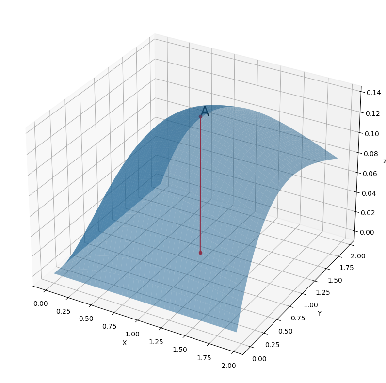

```python
import math
import numpy as np
import matplotlib.pyplot as plt

# Définition de la fonction f(x,y)
def f(x, y):
    return x * y * np.exp(-1 * (x + y))

# Points A et B
A = (1, 1, math.exp(-2))
B = (1, 1, 0)

# Coordonnées x, y et z pour la fonction f(x,y)
x = y = np.arange(0.0, 2.0, 0.05)
X, Y = np.meshgrid(x, y)
Z = f(X, Y)

# Affichage de la fonction f(x,y) en 3D
fig = plt.figure()
ax = fig.add_subplot(111, projection='3d')
# Change transparence map
ax.plot_surface(X, Y, Z, alpha=0.5)

# Affichage des points A et B
ax.scatter(A[0], A[1], A[2], c='r', marker='o')
# Add big annotation
ax.text(A[0], A[1], A[2], 'A', size=20, zorder=1, color='k')
ax.scatter(B[0], B[1], B[2], c='r', marker='o')

# Affichage du segment entre A et B
ax.plot([A[0], B[0]], [A[1], B[1]], [A[2], B[2]], c='r')

# Paramètres de l'affichage
ax.set_xlabel('X')
ax.set_ylabel('Y')
ax.set_zlabel('Z')
# Change fig size
fig.set_size_inches(10, 10)
plt.show()
```